# Personal_Loan_Campaign_Modelling_v2_Soumiya

## Background and Context

AllLife Bank is a US bank that has a growing customer base. The majority of these customers are liability customers (depositors) with varying sizes of deposits. The number of customers who are also borrowers (asset customers) is quite small, and the bank is interested in expanding this base rapidly to bring in more loan business and in the process, earn more through the interest on loans. In particular, the management wants to explore ways of converting its liability customers to personal loan customers (while retaining them as depositors).

A campaign that the bank ran last year for liability customers showed a healthy conversion rate of over 9% success. This has encouraged the retail marketing department to devise campaigns with better target marketing to increase the success ratio.

You as a Data scientist at AllLife bank have to build a model that will help the marketing department to identify the potential customers who have a higher probability of purchasing the loan.

### Objective

To predict whether a liability customer will buy a personal loan or not. Which variables are most significant. Which segment of customers should be targeted more.

### Data Dictionary

- ID: Customer ID
- Age: Customer’s age in completed years
- Experience: #years of professional experience
- Income: Annual income of the customer (in thousand dollars)
- ZIP Code: Home Address ZIP code.
- Family: the Family size of the customer
- CCAvg: Average spending on credit cards per month (in thousand dollars)
- Education: Education Level. 1: Undergrad; 2: Graduate;3: Advanced/Professional
- Mortgage: Value of house mortgage if any. (in thousand dollars)
- Personal_Loan: Did this customer accept the personal loan offered in the last campaign?
- Securities_Account: Does the customer have securities account with the bank?
- CD_Account: Does the customer have a certificate of deposit (CD) account with the bank?
- Online: Do customers use internet banking facilities?
- CreditCard: Does the customer use a credit card issued by any other Bank (excluding All life Bank)?

```python
# Let's import the required libraries

import numpy as np # linear algebra
import pandas as pd # data processing, CSV file I/O (e.g. pd.read_csv)
import matplotlib.pyplot as plt       # matplotlib.pyplot plots data
%matplotlib inline
import seaborn as sns
from sklearn.model_selection import train_test_split
from sklearn.tree import DecisionTreeClassifier
from sklearn import tree
import warnings
warnings.filterwarnings('ignore')
from matplotlib.pyplot import figure


# for statistical analysis
import statsmodels.stats.api as sms
from statsmodels.stats.outliers_influence import variance_inflation_factor
from statsmodels.tools.tools import add_constant


# To get diferent metric scores
from sklearn import metrics
from sklearn.metrics import accuracy_score, recall_score, precision_score, roc_auc_score, roc_curve, confusion_matrix, precision_recall_curve
from sklearn.model_selection import GridSearchCV
```

### Load and explore data

```python
# Import the data set
pdata = pd.read_csv("Loan_Modelling.csv")
```

```python
# Check number of columns and rows in data frame

print(f'There are {pdata.shape[0]} rows and {pdata.shape[1]} columns.')
```

```
There are 5000 rows and 14 columns.
```

```python
# To check first 5 rows of data set
pdata.head()
```

|  | ID | Age | Experience | Income | ZIPCode | Family | CCAvg | Education | Mortgage | Personal_Loan | Securities_Account | CD_Account | Online | CreditCard |
| --- | --- | --- | --- | --- | --- | --- | --- | --- | --- | --- | --- | --- | --- | --- |
| 0 | 1 | 25 | 1 | 49 | 91107 | 4 | 1.6 | 1 | 0 | 0 | 1 | 0 | 0 | 0 |
| 1 | 2 | 45 | 19 | 34 | 90089 | 3 | 1.5 | 1 | 0 | 0 | 1 | 0 | 0 | 0 |
| 2 | 3 | 39 | 15 | 11 | 94720 | 1 | 1.0 | 1 | 0 | 0 | 0 | 0 | 0 | 0 |
| 3 | 4 | 35 | 9 | 100 | 94112 | 1 | 2.7 | 2 | 0 | 0 | 0 | 0 | 0 | 0 |
| 4 | 5 | 35 | 8 | 45 | 91330 | 4 | 1.0 | 2 | 0 | 0 | 0 | 0 | 0 | 1 |

```python
pdata.isnull().values.any() # If there are any null values in data set
```

```
False
```

```python
pdata.isna().sum()
```

```
ID                    0
Age                   0
Experience            0
Income                0
ZIPCode               0
Family                0
CCAvg                 0
Education             0
Mortgage              0
Personal_Loan         0
Securities_Account    0
CD_Account            0
Online                0
CreditCard            0
dtype: int64
```

## Observations:

1. There are no null values

```python
#Let's drop ID as its a redundant column (we have row index) that we won't be using
pdata.drop('ID', inplace=True, axis=1)
```

```python
#Since we have ZIP Codes in the dataset, lets convert them to cities so that we can see the population in more readable "city name" format than ZIPCode.

#pip install pyzipcode

#Import the library to convert zip Code into cities
from pyzipcode import ZipCodeDatabase
zcdb = ZipCodeDatabase()
```

```python
# Let's write function to convert zip code into cities with the database object that was initialized in previous step from pyzipcode library's ZIPCodeDatabase

def zipcode_to_city(zipcode):
    try:
        cities[zipcode]=zcdb[zipcode].city
        return cities[zipcode]
    except:
        print (f'{zipcode} not found')
```

```python
# Let's write function to convert zip code into cities with the database object that was initialized in previous step from pyzipcode library's ZIPCodeDatabase

def zipcode_to_state(zipcode):
    try:
        cities[zipcode]=zcdb[zipcode].state
        return cities[zipcode]
    except:
        print (f'{zipcode} not found')
```

```python
#Create loc list from ZIPCode column, we will setup the city names associated with the ZIP Code using function "zipcode_to_city" defined in previous step.
loc = pdata.ZIPCode.tolist()
cities = dict()

for cn in loc:
    cities[cn] = zipcode_to_city(cn)
```

```
92717 not found
92717 not found
92717 not found
92717 not found
92717 not found
93077 not found
92634 not found
92717 not found
96651 not found
96651 not found
92717 not found
92717 not found
92634 not found
92717 not found
92717 not found
```

[output cut: 19 more lines]

## Observations:

1. Looks like some of the ZIP Code are missing from the ZIP Code Database as they are throwing error while converting into US cities.
2. Upon further research I found that these zip codes do not belong to United States.
3. Since these ZIPCode are not US Zip code, we will drop the rows with these zip code, since we are doing EDA and modelling for US Bank and its Cutomers

```python
#Let's find the index of rows with these ZIP Codes.

index_names = pdata[ (pdata['ZIPCode'] == 92717) | (pdata['ZIPCode'] == 93077)|(pdata['ZIPCode'] == 92634) |(pdata['ZIPCode'] == 96651)].index
```

```python
len(index_names)
```

```
34
```

## Observations:

1. There are 34 rows that have the ZIP Codes- 92717, 93077, 92634 and 96651

```python
# Dropping the rows with index in "index_names" list
pdata.drop(index_names, inplace = True)
```

```python
#Lets try converting ZIP Code to city again.
loc = pdata.ZIPCode.tolist()
cities = dict()

for cn in loc:
    cities[cn] = zipcode_to_state(cn)
```

```python
#Let's print our ZIPCode and City dictionary
cities
```

```
{91107: 'CA',
 90089: 'CA',
 94720: 'CA',
 94112: 'CA',
 91330: 'CA',
 92121: 'CA',
 91711: 'CA',
 93943: 'CA',
 93023: 'CA',
 94710: 'CA',
 90277: 'CA',
 93106: 'CA',
 94920: 'CA',
 91741: 'CA',
 95054: 'CA',
```

[output cut: 448 more lines]

## Observations:

1. All the ZIP Codes belong to California (CA) State, lets populate the cities instead for the ZIP Codes.

```python
#Lets try converting ZIP Code to city again.
loc = pdata.ZIPCode.tolist()
cities = dict()

for cn in loc:
    cities[cn] = zipcode_to_city(cn)
```

```python
#Let's print our ZIPCode and City dictionary
cities
```

```
{91107: 'Pasadena',
 90089: 'Los Angeles',
 94720: 'Berkeley',
 94112: 'San Francisco',
 91330: 'Northridge',
 92121: 'San Diego',
 91711: 'Claremont',
 93943: 'Monterey',
 93023: 'Ojai',
 94710: 'Berkeley',
 90277: 'Redondo Beach',
 93106: 'Santa Barbara',
 94920: 'Belvedere Tiburon',
 91741: 'Glendora',
 95054: 'Santa Clara',
```

[output cut: 448 more lines]

#### Now we have the dictionary of ZIP Code and Corresponding cities, let's add the city values for corresponding ZIP code in the dataset.

```python
#Let's add the city column to the data set
pdata['City'] = pdata['ZIPCode'].map(cities)
```

```python
#We can drop the ZIP Code column as we have extracted city information from that column
pdata.drop('ZIPCode',inplace=True, axis=1)
```

```python
#Here is the list of columns (features) we have in the dataset
pdata.columns
```

```
Index(['Age', 'Experience', 'Income', 'Family', 'CCAvg', 'Education',
       'Mortgage', 'Personal_Loan', 'Securities_Account', 'CD_Account',
       'Online', 'CreditCard', 'City'],
      dtype='object')
```

```python
pdata.describe()
```

|  | Age | Experience | Income | Family | CCAvg | Education | Mortgage | Personal_Loan | Securities_Account | CD_Account | Online | CreditCard |
| --- | --- | --- | --- | --- | --- | --- | --- | --- | --- | --- | --- | --- |
| count | 4966.000000 | 4966.000000 | 4966.000000 | 4966.000000 | 4966.000000 | 4966.000000 | 4966.000000 | 4966.000000 | 4966.000000 | 4966.000000 | 4966.000000 | 4966.000000 |
| mean | 45.353806 | 20.119815 | 73.827829 | 2.397100 | 1.937016 | 1.880387 | 56.668747 | 0.096053 | 0.104108 | 0.060814 | 0.596859 | 0.293596 |
| std | 11.462759 | 11.467874 | 46.042272 | 1.147607 | 1.743928 | 0.840197 | 101.865399 | 0.294694 | 0.305431 | 0.239012 | 0.490578 | 0.455455 |
| min | 23.000000 | -3.000000 | 8.000000 | 1.000000 | 0.000000 | 1.000000 | 0.000000 | 0.000000 | 0.000000 | 0.000000 | 0.000000 | 0.000000 |
| 25% | 35.000000 | 10.000000 | 39.000000 | 1.000000 | 0.700000 | 1.000000 | 0.000000 | 0.000000 | 0.000000 | 0.000000 | 0.000000 | 0.000000 |
| 50% | 45.000000 | 20.000000 | 64.000000 | 2.000000 | 1.500000 | 2.000000 | 0.000000 | 0.000000 | 0.000000 | 0.000000 | 1.000000 | 0.000000 |
| 75% | 55.000000 | 30.000000 | 98.000000 | 3.000000 | 2.500000 | 3.000000 | 101.000000 | 0.000000 | 0.000000 | 0.000000 | 1.000000 | 1.000000 |
| max | 67.000000 | 43.000000 | 224.000000 | 4.000000 | 10.000000 | 3.000000 | 635.000000 | 1.000000 | 1.000000 | 1.000000 | 1.000000 | 1.000000 |

## Observations:

```python
#Let's investigate the dependent variable
#Personal_Loan is the dependent variable, lets see how many unique values are present
pdata['Personal_Loan'].value_counts() #1=Yes, 0=No
```

```
0    4489
1     477
Name: Personal_Loan, dtype: int64
```

```python
#percentage of people who did not accept loan
pdata['Personal_Loan'].value_counts()[0]/5000*100
```

```
89.78
```

```python
#percentage of people who accepted loan
pdata['Personal_Loan'].value_counts()[1]/5000*100
```

```
9.54
```

## Observations:

1. The dependent variable has 2 unique values 0 and 1. Let's calculate the percentage of these uniques values.
2. Out of complete dataset, there are 89.78% rows that have 0 (False) and 9.54% 1 (True) value of dependent variable.

```python
#Since negative experience is an anomoly, let's replace the negative values with nan, which we can treat later.
pdata.Experience[pdata['Experience'] < 0] = np.nan
```

```python
pdata['Experience'].unique()
```

```
array([ 1., 19., 15.,  9.,  8., 13., 27., 24., 10., 39.,  5., 23., 32.,
       41., 30., 14., 18., 21., 28., 31., 11., 16., 20., 35.,  6., 25.,
        7., 12., 26., 37., 17.,  2., 36., 29.,  3., 22., nan, 34.,  0.,
       38., 40., 33.,  4., 42., 43.])
```

```python
pdata.isna().sum()
```

```
Age                    0
Experience            51
Income                 0
Family                 0
CCAvg                  0
Education              0
Mortgage               0
Personal_Loan          0
Securities_Account     0
CD_Account             0
Online                 0
CreditCard             0
City                   0
dtype: int64
```

```python
#Since Experience depends on Age and we can't have a 25 year old person with
#20 years of experience, let's impute the Experince median value based on the age of the person.

pdata['Experience'] = pdata.groupby(['Age'])['Experience'].transform(lambda x: x.fillna(x.median()))
```

```python
pdata.isna().sum()
```

```
Age                    0
Experience            12
Income                 0
Family                 0
CCAvg                  0
Education              0
Mortgage               0
Personal_Loan          0
Securities_Account     0
CD_Account             0
Online                 0
CreditCard             0
City                   0
dtype: int64
```

```python
#There are still some na values that were not imputed as Age might not be present for all Experience (na values)


index_names_exp = pdata[ (pdata['Experience'].isna()) ].index
```

```python
len(index_names_exp)
```

```
12
```

```python
# Dropping the rows with index in "index_names_exp" list
pdata.drop(index_names_exp, inplace = True)
```

```python
pdata.isna().sum()
```

```
Age                   0
Experience            0
Income                0
Family                0
CCAvg                 0
Education             0
Mortgage              0
Personal_Loan         0
Securities_Account    0
CD_Account            0
Online                0
CreditCard            0
City                  0
dtype: int64
```

## Observations:

1. There are no more na values in the dataset.

```python
pdata.describe()
```

|  | Age | Experience | Income | Family | CCAvg | Education | Mortgage | Personal_Loan | Securities_Account | CD_Account | Online | CreditCard |
| --- | --- | --- | --- | --- | --- | --- | --- | --- | --- | --- | --- | --- |
| count | 4954.000000 | 4954.000000 | 4954.000000 | 4954.000000 | 4954.000000 | 4954.000000 | 4954.000000 | 4954.000000 | 4954.000000 | 4954.000000 | 4954.000000 | 4954.000000 |
| mean | 45.407953 | 20.190149 | 73.843763 | 2.395640 | 1.935626 | 1.881510 | 56.631813 | 0.096286 | 0.103956 | 0.060961 | 0.596690 | 0.293298 |
| std | 11.423642 | 11.400257 | 46.045166 | 1.147381 | 1.742997 | 0.840554 | 101.862881 | 0.295013 | 0.305235 | 0.239283 | 0.490612 | 0.455320 |
| min | 24.000000 | 0.000000 | 8.000000 | 1.000000 | 0.000000 | 1.000000 | 0.000000 | 0.000000 | 0.000000 | 0.000000 | 0.000000 | 0.000000 |
| 25% | 35.000000 | 10.000000 | 39.000000 | 1.000000 | 0.700000 | 1.000000 | 0.000000 | 0.000000 | 0.000000 | 0.000000 | 0.000000 | 0.000000 |
| 50% | 45.000000 | 20.000000 | 64.000000 | 2.000000 | 1.500000 | 2.000000 | 0.000000 | 0.000000 | 0.000000 | 0.000000 | 1.000000 | 0.000000 |
| 75% | 55.000000 | 30.000000 | 98.000000 | 3.000000 | 2.500000 | 3.000000 | 101.000000 | 0.000000 | 0.000000 | 0.000000 | 1.000000 | 1.000000 |
| max | 67.000000 | 43.000000 | 224.000000 | 4.000000 | 10.000000 | 3.000000 | 635.000000 | 1.000000 | 1.000000 | 1.000000 | 1.000000 | 1.000000 |

## Observations:

1. Now the Experience column's min value is 0 rather than a negative value.
2. Now lets look at the data types of the columns.

```python
pdata.info()
```

```
<class 'pandas.core.frame.DataFrame'>
Int64Index: 4954 entries, 0 to 4999
Data columns (total 13 columns):
 #   Column              Non-Null Count  Dtype
---  ------              --------------  -----
 0   Age                 4954 non-null   int64
 1   Experience          4954 non-null   float64
 2   Income              4954 non-null   int64
 3   Family              4954 non-null   int64
 4   CCAvg               4954 non-null   float64
 5   Education           4954 non-null   int64
 6   Mortgage            4954 non-null   int64
 7   Personal_Loan       4954 non-null   int64
 8   Securities_Account  4954 non-null   int64
 9   CD_Account          4954 non-null   int64
 10  Online              4954 non-null   int64
 11  CreditCard          4954 non-null   int64
 12  City                4954 non-null   object
dtypes: float64(2), int64(10), object(1)
memory usage: 541.8+ KB
```

```python
pdata["Family"] = pdata["Family"].astype("category")
pdata["Education"] = pdata["Education"].astype("category")
pdata["City"] = pdata["City"].astype("category")
```

```python
pdata["Personal_Loan"] = pdata["Personal_Loan"].astype("bool")
pdata["Securities_Account"] = pdata["Securities_Account"].astype("bool")
pdata["CD_Account"] = pdata["CD_Account"].astype("bool")
pdata["Online"] = pdata["Online"].astype("bool")
pdata["CreditCard"] = pdata["CreditCard"].astype("bool")
```

```python
pdata.info()
```

```
<class 'pandas.core.frame.DataFrame'>
Int64Index: 4954 entries, 0 to 4999
Data columns (total 13 columns):
 #   Column              Non-Null Count  Dtype
---  ------              --------------  -----
 0   Age                 4954 non-null   int64
 1   Experience          4954 non-null   float64
 2   Income              4954 non-null   int64
 3   Family              4954 non-null   category
 4   CCAvg               4954 non-null   float64
 5   Education           4954 non-null   category
 6   Mortgage            4954 non-null   int64
 7   Personal_Loan       4954 non-null   bool
 8   Securities_Account  4954 non-null   bool
 9   CD_Account          4954 non-null   bool
 10  Online              4954 non-null   bool
 11  CreditCard          4954 non-null   bool
 12  City                4954 non-null   category
dtypes: bool(5), category(3), float64(2), int64(3)
memory usage: 286.1 KB
```

## Observations:

1. Family, Education and City are Categorical columns.
2. Personal_Loan, Securities_Account, CD_Account, Online and CreditCard are Boolean values.
3. Age, Income and Mortgage is Integer type
4. Experience and CCAvg are of float type.

```python
# Check the unique values in each column of the dataframe.
pdata.nunique()
```

```
Age                    44
Experience             44
Income                162
Family                  4
CCAvg                 107
Education               3
Mortgage              347
Personal_Loan           2
Securities_Account      2
CD_Account              2
Online                  2
CreditCard              2
City                  242
dtype: int64
```

## Observations:

1. Personal_Loan, Securities_Account, CD_Account, Online and CreditCard each have 2 unique values (0 & 1).
2. Family has 4 unique values (1-4)
3. Education has 3 unique values (1-3)
4. Age and Experience both have 44 unique values.
5. Income has 162 unique values.
6. CCAvg has 107 unique values.
7. Mortgage has 347 unique values.
8. We have 242 unique cities in the dataset. Previoulsy we saw that all the cities are in CA state.

# EDA Univariate

```python
pdata.skew()
```

```
Age                  -0.027187
Experience           -0.015141
Income                0.842089
CCAvg                 1.597098
Mortgage              2.102794
Personal_Loan         2.738034
Securities_Account    2.596058
CD_Account            3.671111
Online               -0.394318
CreditCard            0.908307
dtype: float64
```

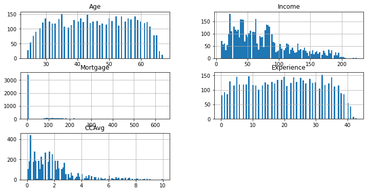

```python
# Lets map the count for Int and Float values.

columns=['Age','Income','Mortgage','Experience','CCAvg']
pdata[columns].hist(stacked=False, bins=100, figsize=(12,30), layout=(14,2));
```

## Observations:

1. Mortage is highly right skewed that we saw previouly as well.
2. CCAvg is also right skewed.

```python
# While doing uni-variate analysis of numerical variables we want to study their central tendency
# and dispersion.
# Let us write a function that will help us create boxplot and histogram for any input numerical
# variable.
# This function takes the numerical column as the input and returns the boxplots
# and histograms for the variable.
# Let us see if this help us write faster and cleaner code.
def histogram_boxplot(feature, figsize=(15,10), bins = None):
    """ Boxplot and histogram combined
    feature: 1-d feature array
    figsize: size of fig (default (9,8))
    bins: number of bins (default None / auto)
    """
    f2, (ax_box2, ax_hist2) = plt.subplots(nrows = 2, # Number of rows of the subplot grid= 2
                                           sharex = True, # x-axis will be shared among all subplots
                                           gridspec_kw = {"height_ratios": (.25, .75)},
                                           figsize = figsize
                                           ) # creating the 2 subplots
    sns.boxplot(feature, ax=ax_box2, showmeans=True, color='violet') # boxplot will be created and a star will indicate the mean value of the column
    sns.distplot(feature, kde=F, ax=ax_hist2, bins=bins,palette="winter") if bins else sns.distplot(feature, kde=False, ax=ax_hist2) # For histogram
    ax_hist2.axvline(np.mean(feature), color='green', linestyle='--') # Add mean to the histogram
    ax_hist2.axvline(np.median(feature), color='black', linestyle='-') # Add median to the histogram
```

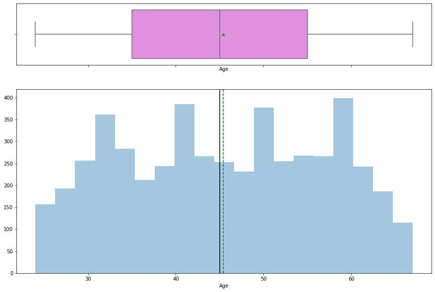

```python
histogram_boxplot(pdata["Age"])
```

## Observations:

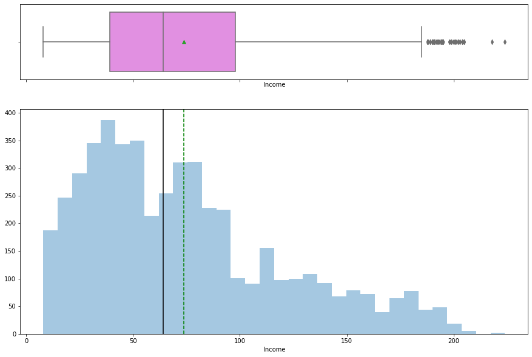

```python
histogram_boxplot(pdata["Income"])
```

## Observervations:

1. Income has few outliers and is slightly right skewed.

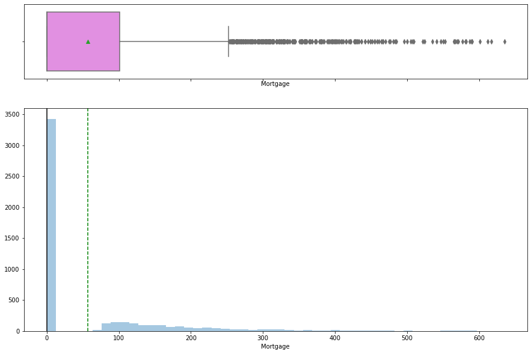

```python
histogram_boxplot(pdata["Mortgage"])
```

## Observations:

1. Mortgage has lot of outliers and is highly right skewed.

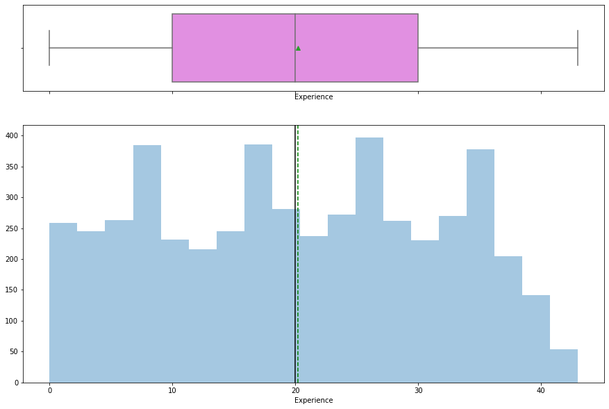

```python
histogram_boxplot(pdata["Experience"])
```

## Observations:

1. Experience has no outliers.

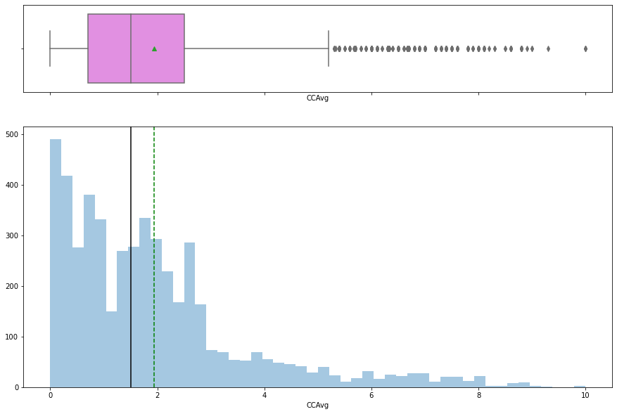

```python
histogram_boxplot(pdata["CCAvg"])
```

## Observations:

1. CCAvg had lot of outliers and is highly right skewed.

```python
# Function to create barplots that indicate percentage for each category.

def perc_on_bar(plot, feature):
    '''
    plot
    feature: categorical feature
    the function won't work if a column is passed in hue parameter
    '''
    total = len(feature) # length of the column
    for p in ax.patches:
        percentage = '{:.1f}%'.format(100 * p.get_height()/total) # percentage of each class of the category
        x = p.get_x() + p.get_width() / 2 - 0.05 # width of the plot
        y = p.get_y() + p.get_height()           # hieght of the plot
        ax.annotate(percentage, (x, y), size = 12) # annotate the percantage
    plt.show() # show the plot
```

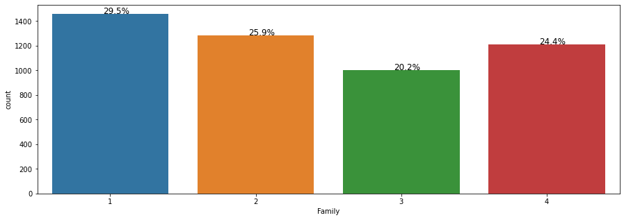

```python
plt.figure(figsize=(15,5))
ax = sns.countplot(pdata["Family"])
perc_on_bar(ax,pdata["Family"])
```

## Observations:

1. Family of 1 person is the most connon occurance followed by family of 2, family of 4 and lastly fmaily of 3.

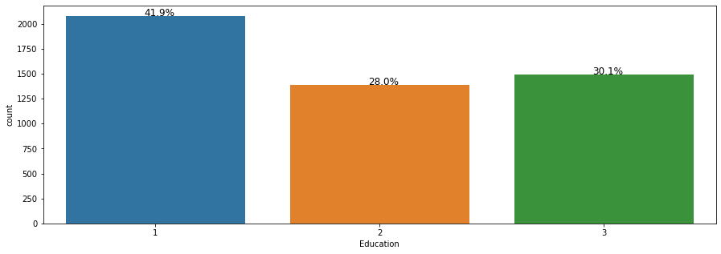

```python
plt.figure(figsize=(15,5))
ax = sns.countplot(pdata["Education"])
perc_on_bar(ax,pdata["Education"])
```

## Observations:

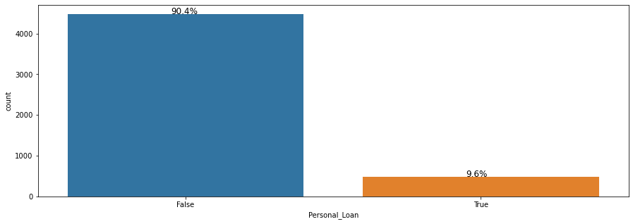

```python
plt.figure(figsize=(15,5))
ax = sns.countplot(pdata["Personal_Loan"])
perc_on_bar(ax,pdata["Personal_Loan"])
```

## Observations:

1. 90.4% people did not accept personal load when offered and only 9.6% people accepted the loan.

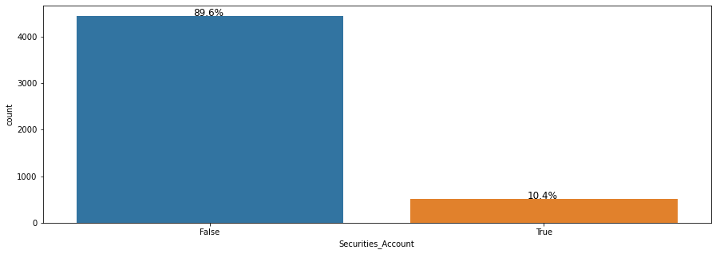

```python
plt.figure(figsize=(15,5))
ax = sns.countplot(pdata["Securities_Account"])
perc_on_bar(ax,pdata["Securities_Account"])
```

## Observations:

1. 89.6% people do not have Securities Account and only 10.4% people have securities account.

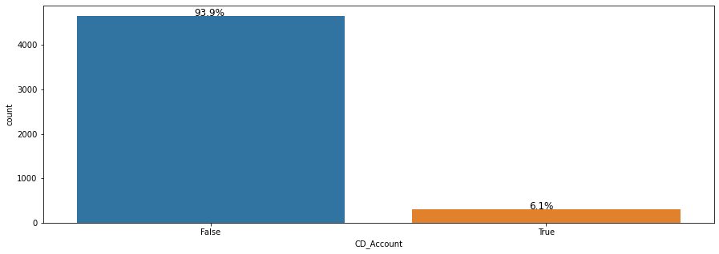

```python
plt.figure(figsize=(15,5))
ax = sns.countplot(pdata["CD_Account"])
perc_on_bar(ax,pdata["CD_Account"])
```

## Observations:

1. 93.9 % people do not have CD Account and only 6.1% people have it.

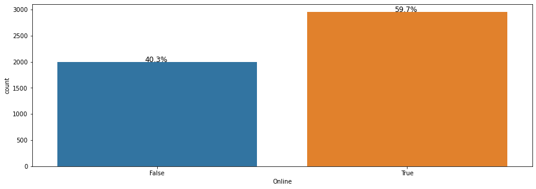

```python
plt.figure(figsize=(15,5))
ax = sns.countplot(pdata["Online"])
perc_on_bar(ax,pdata["Online"])
```

## Observations:

1. 59.7% people use online banking vs 40.3% do not use it.

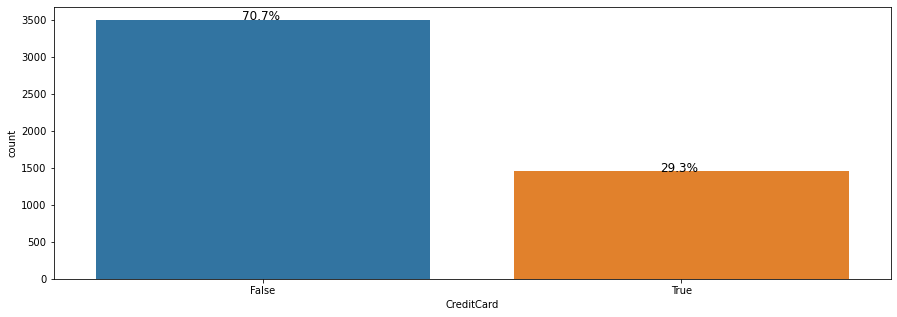

```python
plt.figure(figsize=(15,5))
ax = sns.countplot(pdata["CreditCard"])
perc_on_bar(ax,pdata["CreditCard"])
```

## Observations:

70.7% people do not have Credit card from other banks vs 29.3% people have it.

```
There are 242 unique cities.

Los Angeles               375
San Diego                 267
San Francisco             257
Berkeley                  240
Sacramento                148
Palo Alto                 130
Stanford                  127
Davis                     121
La Jolla                  112
Santa Barbara             103
San Jose                   96
Santa Clara                77
Monterey                   72
Pasadena                   71
Irvine                     58
Oakland                    55
Newbury Park               53
Menlo Park                 52
Claremont                  51
Santa Cruz                 50
El Segundo                 50
Northridge                 48
Riverside                  46
Hayward                    41
Redwood City               37
Los Altos                  36
Santa Monica               35
Huntington Beach           35
Emeryville                 34
Livermore                  34
San Luis Obispo            33
Fallbrook                  32
Fremont                    31
Goleta                     31
Cupertino                  29
Carlsbad                   28
Torrance                   28
Alameda                    26
```

[output cut: 190 more lines]

```
Half Moon Bay               2
Upland                      2
Ukiah                       2
Inglewood                   2
Moraga                      2
Morgan Hill                 2
Oxnard                      2
Pacific Palisades           2
South Gate                  2
Ladera Ranch                1
Tahoe City                  1
Stinson Beach               1
Sierra Madre                1
Sausalito                   1
Name: City, dtype: int64
```

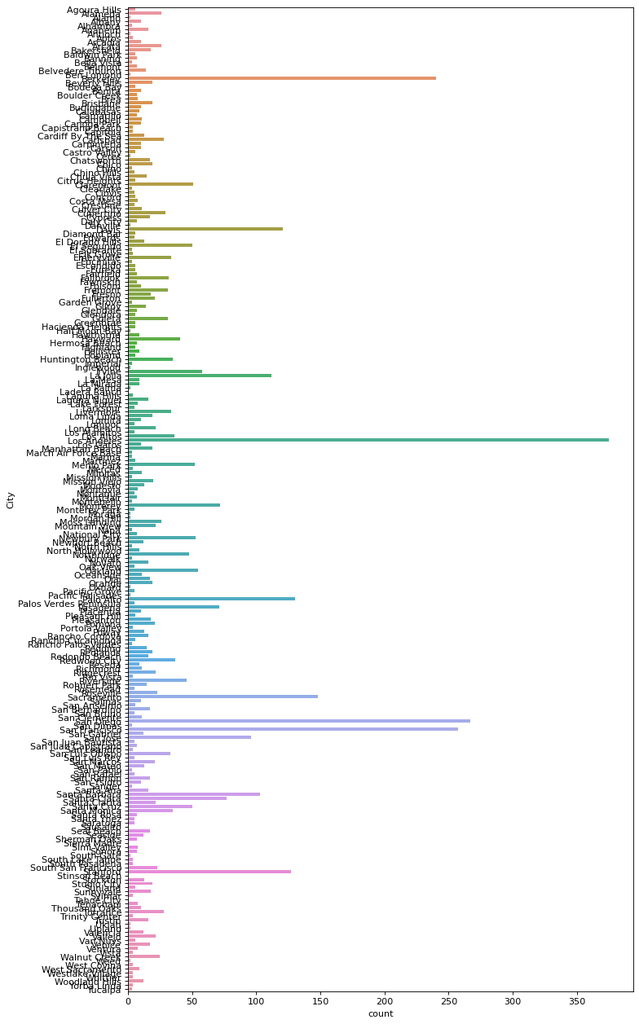

```python
figure(figsize=(10, 20), dpi=80)
print(f'There are {pdata.City.nunique()} unique cities.')
print(' ')
print(f'{pdata.City.value_counts(ascending=False)}')
sns.countplot(y=pdata['City']);
```

## Observations:

1. There are 242 unique cities in the dataset, this might overfit the decision tree model. Logistic may not have optimum AOC because of the noise created by so many predictors.

# EDA Multivariate

```python
pdata.corr() # It will show correlation matrix
```

|  | Age | Experience | Income | CCAvg | Mortgage | Personal_Loan | Securities_Account | CD_Account | Online | CreditCard |
| --- | --- | --- | --- | --- | --- | --- | --- | --- | --- | --- |
| Age | 1.000000 | 0.994185 | -0.056338 | -0.049276 | -0.011947 | -0.008602 | -0.000469 | 0.006559 | 0.014773 | 0.009558 |
| Experience | 0.994185 | 1.000000 | -0.047696 | -0.047356 | -0.010288 | -0.008747 | -0.001388 | 0.008554 | 0.014689 | 0.011074 |
| Income | -0.056338 | -0.047696 | 1.000000 | 0.644743 | 0.206897 | 0.503716 | -0.002062 | 0.170148 | 0.015004 | -0.001098 |
| CCAvg | -0.049276 | -0.047356 | 0.644743 | 1.000000 | 0.109840 | 0.367435 | 0.014824 | 0.137912 | -0.002970 | -0.006697 |
| Mortgage | -0.011947 | -0.010288 | 0.206897 | 0.109840 | 1.000000 | 0.141154 | -0.003340 | 0.089288 | -0.003873 | -0.008493 |
| Personal_Loan | -0.008602 | -0.008747 | 0.503716 | 0.367435 | 0.141154 | 1.000000 | 0.023347 | 0.317246 | 0.008898 | 0.003151 |
| Securities_Account | -0.000469 | -0.001388 | -0.002062 | 0.014824 | -0.003340 | 0.023347 | 1.000000 | 0.319568 | 0.013084 | -0.016051 |
| CD_Account | 0.006559 | 0.008554 | 0.170148 | 0.137912 | 0.089288 | 0.317246 | 0.319568 | 1.000000 | 0.176797 | 0.280607 |
| Online | 0.014773 | 0.014689 | 0.015004 | -0.002970 | -0.003873 | 0.008898 | 0.013084 | 0.176797 | 1.000000 | 0.007240 |
| CreditCard | 0.009558 | 0.011074 | -0.001098 | -0.006697 | -0.008493 | 0.003151 | -0.016051 | 0.280607 | 0.007240 | 1.000000 |

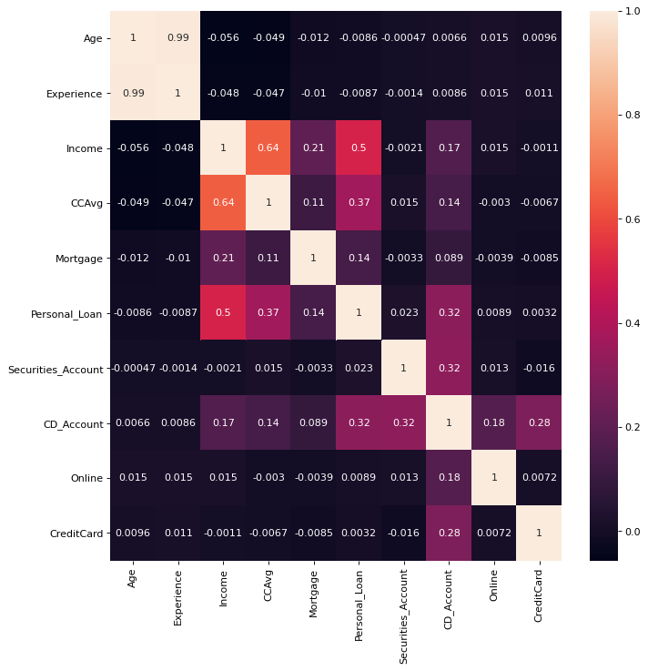

```python
figure(figsize=(10,10), dpi=80)
corr = pdata.corr()
sns.heatmap(corr, annot=True); #correlation matrix between different columns
```

## Observations:

1. Age and Experience are highly correlated, which makes sense.
2. Income and CCAvg also has positive correlation that shows that people with higher income tend to spend more on credit card.

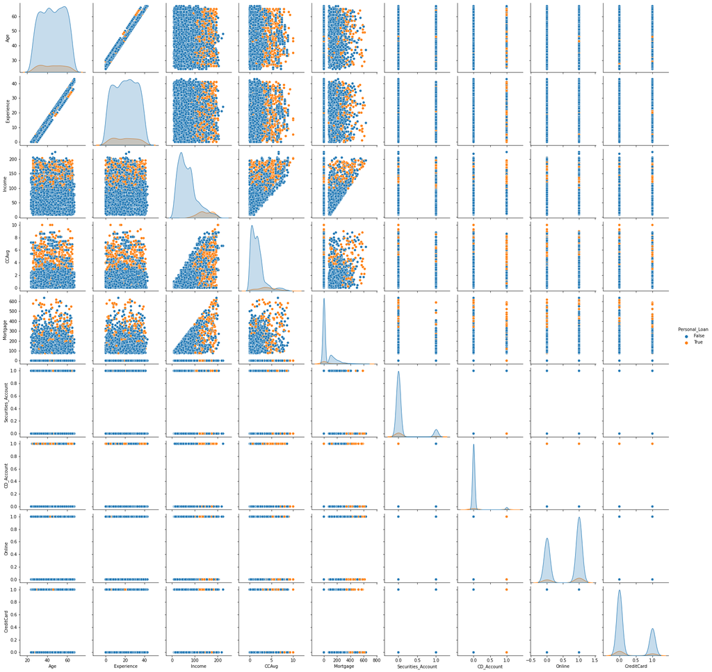

```python
sns.pairplot(pdata,diag_kind='kde', hue='Personal_Loan');
```

## Observations:

1. People with high CCAvg, Income and Mortgage tend to use Personal Loan.

# One Hot Encoding

```python
pdata.info()
```

```
<class 'pandas.core.frame.DataFrame'>
Int64Index: 4954 entries, 0 to 4999
Data columns (total 13 columns):
 #   Column              Non-Null Count  Dtype
---  ------              --------------  -----
 0   Age                 4954 non-null   int64
 1   Experience          4954 non-null   float64
 2   Income              4954 non-null   int64
 3   Family              4954 non-null   category
 4   CCAvg               4954 non-null   float64
 5   Education           4954 non-null   category
 6   Mortgage            4954 non-null   int64
 7   Personal_Loan       4954 non-null   bool
 8   Securities_Account  4954 non-null   bool
 9   CD_Account          4954 non-null   bool
 10  Online              4954 non-null   bool
 11  CreditCard          4954 non-null   bool
 12  City                4954 non-null   category
dtypes: bool(5), category(3), float64(2), int64(3)
memory usage: 415.1 KB
```

```python
#Before further Feature Engineering, lets make a copy of the clean dataset.
df=pdata.copy()
```

```python
#Since City has 242 unique values and can't be binned, we will be dropping City from the dataset for model creation.
df.drop('City',inplace=True, axis=1)
```

```python
#One Hot Encoding for Family and Education
df = pd.get_dummies(df, columns=['Family'])
df = pd.get_dummies(df, columns=['Education'])
```

```python
df.shape
```

```
(4954, 17)
```

```python
df.info()
```

```
<class 'pandas.core.frame.DataFrame'>
Int64Index: 4954 entries, 0 to 4999
Data columns (total 17 columns):
 #   Column              Non-Null Count  Dtype
---  ------              --------------  -----
 0   Age                 4954 non-null   int64
 1   Experience          4954 non-null   float64
 2   Income              4954 non-null   int64
 3   CCAvg               4954 non-null   float64
 4   Mortgage            4954 non-null   int64
 5   Personal_Loan       4954 non-null   bool
 6   Securities_Account  4954 non-null   bool
 7   CD_Account          4954 non-null   bool
 8   Online              4954 non-null   bool
 9   CreditCard          4954 non-null   bool
 10  Family_1            4954 non-null   uint8
 11  Family_2            4954 non-null   uint8
 12  Family_3            4954 non-null   uint8
 13  Family_4            4954 non-null   uint8
 14  Education_1         4954 non-null   uint8
 15  Education_2         4954 non-null   uint8
 16  Education_3         4954 non-null   uint8
dtypes: bool(5), float64(2), int64(3), uint8(7)
memory usage: 419.3 KB
```

### Drop the dummy vars, that will not add any value (if there are n levels in the categorical variable, create n-1 dummy vars for that column.)

```python
df.drop('Family_4',inplace=True, axis=1)
df.drop('Education_3',inplace=True, axis=1)
```

```python
df.info()
```

```
<class 'pandas.core.frame.DataFrame'>
Int64Index: 4954 entries, 0 to 4999
Data columns (total 15 columns):
 #   Column              Non-Null Count  Dtype
---  ------              --------------  -----
 0   Age                 4954 non-null   int64
 1   Experience          4954 non-null   float64
 2   Income              4954 non-null   int64
 3   CCAvg               4954 non-null   float64
 4   Mortgage            4954 non-null   int64
 5   Personal_Loan       4954 non-null   bool
 6   Securities_Account  4954 non-null   bool
 7   CD_Account          4954 non-null   bool
 8   Online              4954 non-null   bool
 9   CreditCard          4954 non-null   bool
 10  Family_1            4954 non-null   uint8
 11  Family_2            4954 non-null   uint8
 12  Family_3            4954 non-null   uint8
 13  Education_1         4954 non-null   uint8
 14  Education_2         4954 non-null   uint8
dtypes: bool(5), float64(2), int64(3), uint8(5)
memory usage: 409.6 KB
```

```python
df[df.isna().any(axis=1)]
```

|  | Age | Experience | Income | CCAvg | Mortgage | Personal_Loan | Securities_Account | CD_Account | Online | CreditCard | Family_1 | Family_2 | Family_3 | Education_1 | Education_2 |
| --- | --- | --- | --- | --- | --- | --- | --- | --- | --- | --- | --- | --- | --- | --- | --- |

## Observations:

1. There is no data with na values.
2. Since Decision trees are adaptive to binning, we will skip the manual binning step.

# Splitting the data

```python
from sklearn.model_selection import train_test_split

X = df.drop('Personal_Loan',axis=1)     # Predictor feature columns (8 X m)
Y = df['Personal_Loan']   # Predicted class (1=True, 0=False) (1 X m)

x_train, x_test, y_train, y_test = train_test_split(X, Y, test_size=0.3, random_state=1)
# 1 is just any random seed number

x_train.head()
```

|  | Age | Experience | Income | CCAvg | Mortgage | Securities_Account | CD_Account | Online | CreditCard | Family_1 | Family_2 | Family_3 | Education_1 | Education_2 |
| --- | --- | --- | --- | --- | --- | --- | --- | --- | --- | --- | --- | --- | --- | --- |
| 4496 | 51 | 25.0 | 45 | 2.6 | 0 | False | False | False | False | 0 | 0 | 0 | 1 | 0 |
| 3868 | 41 | 16.0 | 44 | 0.3 | 0 | False | False | False | False | 1 | 0 | 0 | 0 | 0 |
| 2737 | 57 | 31.0 | 159 | 0.5 | 0 | False | False | False | False | 0 | 1 | 0 | 1 | 0 |
| 1929 | 44 | 19.0 | 30 | 0.6 | 0 | False | False | True | False | 1 | 0 | 0 | 0 | 0 |
| 3286 | 62 | 36.0 | 58 | 2.8 | 0 | False | False | False | True | 1 | 0 | 0 | 0 | 1 |

```python
print("{0:0.2f}% data is in training set".format((len(x_train)/len(df.index)) * 100))
print("{0:0.2f}% data is in test set".format((len(x_test)/len(df.index)) * 100))

print("Original Personal_Loan True Values    : {0} ({1:0.2f}%)".format(len(df.loc[pdata['Personal_Loan'] == 1]), (len(df.loc[df['Personal_Loan'] == 1])/len(df.index)) * 100))
print("Original Personal_Loan False Values   : {0} ({1:0.2f}%)".format(len(df.loc[pdata['Personal_Loan'] == 0]), (len(df.loc[df['Personal_Loan'] == 0])/len(df.index)) * 100))
print("")
print("Training Personal_Loan True Values    : {0} ({1:0.2f}%)".format(len(y_train[y_train[:] == 1]), (len(y_train[y_train[:] == 1])/len(y_train)) * 100))
print("Training Personal_Loan False Values   : {0} ({1:0.2f}%)".format(len(y_train[y_train[:] == 0]), (len(y_train[y_train[:] == 0])/len(y_train)) * 100))
print("")
print("Test Personal_Loan True Values        : {0} ({1:0.2f}%)".format(len(y_test[y_test[:] == 1]), (len(y_test[y_test[:] == 1])/len(y_test)) * 100))
print("Test Personal_Loan False Values       : {0} ({1:0.2f}%)".format(len(y_test[y_test[:] == 0]), (len(y_test[y_test[:] == 0])/len(y_test)) * 100))
print("")
```

```
69.98% data is in training set
30.02% data is in test set
Original Personal_Loan True Values    : 477 (9.63%)
Original Personal_Loan False Values   : 4477 (90.37%)

Training Personal_Loan True Values    : 329 (9.49%)
Training Personal_Loan False Values   : 3138 (90.51%)

Test Personal_Loan True Values        : 148 (9.95%)
Test Personal_Loan False Values       : 1339 (90.05%)
```

# Logistic Regression

### Before making the model, first let's check if our variables has multicollinearity

- There are different ways of detecting (or testing) multi-collinearity, one such way is Variation Inflation Factor.
- **Variance Inflation factor**: Variance inflation factors measure the inflation in the variances of the regression coefficients estimates due to collinearities that exist among the predictors. It is a measure of how much the variance of the estimated regression coefficient βk is “inflated”by the existence of correlation among the predictor variables in the model.
- General Rule of thumb: If VIF is 1 then there is no correlation among the kth predictor and the remaining predictor variables, and hence the variance of β̂k is not inflated at all. Whereas if VIF exceeds 5, we say there is moderate VIF and if it is 10 or exceeding 10, it shows signs of high multi-collinearity. But the purpose of the analysis should dictate which threshold to use.

```python
##  Function to calculate different metric scores of the model - Accuracy, Recall and Precision
def get_metrics_score(model,train,test,train_y,test_y,flag=True):
    '''
    model : classifier to predict values of X

    '''
    # defining an empty list to store train and test results

    score_list=[]

    pred_train = model.predict(train)
    pred_test = model.predict(test)

    train_acc = accuracy_score(pred_train,train_y)
    test_acc = accuracy_score(pred_test,test_y)

    train_recall = recall_score(train_y,pred_train)
    test_recall = recall_score(test_y,pred_test)

    train_precision = precision_score(train_y,pred_train)
    test_precision = precision_score(test_y,pred_test)



    score_list.extend((train_acc,test_acc,train_recall,test_recall,train_precision,test_precision))

     # If the flag is set to True then only the following print statements will be dispayed. The default value is set to True.
    if flag == True:
        print("Accuracy on training set : ",accuracy_score(pred_train,train_y))
        print("Accuracy on test set : ",accuracy_score(pred_test,test_y))
        print("Recall on training set : ",recall_score(train_y,pred_train))
        print("Recall on test set : ",recall_score(test_y,pred_test))
        print("Precision on training set : ",precision_score(train_y,pred_train))
        print("Precision on test set : ",precision_score(test_y,pred_test))

    return score_list # returning the list with train and test scores
```

```python
# dataframe with numerical column only
num_feature_set = X.copy()
num_feature_set = add_constant(num_feature_set)
num_feature_set = num_feature_set.astype(float)
```

```python
vif_series1 = pd.Series([variance_inflation_factor(num_feature_set.values,i) for i in range(num_feature_set.shape[1])],index=num_feature_set.columns, dtype = float)
print('Series before feature selection: \n\n{}\n'.format(vif_series1))
```

```
Series before feature selection:

const                 486.816659
Age                    93.229147
Experience             93.074760
Income                  1.870271
CCAvg                   1.725687
Mortgage                1.051756
Securities_Account      1.140754
CD_Account              1.341390
Online                  1.040378
CreditCard              1.112163
Family_1                1.605876
Family_2                1.600397
Family_3                1.473534
Education_1             1.537704
Education_2             1.433467
dtype: float64
```

## Observations:

1. Age and Experience have high multicolinearity